# 重賞レース予測レポート【レース終了】

作成日時: 2026/07/19 16:21:43

☞ [マニュアル(pdf)](https://ryutoro-galois.github.io/keiba-predictor/manual/manual.pdf)

☞ 過去6年の同一レース結果: [2025年](https://ryutoro-galois.github.io/keiba-predictor/report/PredResult_2025y_raceDate_20250720_20250720.html), [2024年](https://ryutoro-galois.github.io/keiba-predictor/report/PredResult_2024y_raceDate_20240721_20240721.html), [2023年](https://ryutoro-galois.github.io/keiba-predictor/report/PredResult_2023y_raceDate_20230715_20230716.html), [2022年](https://ryutoro-galois.github.io/keiba-predictor/report/PredResult_2022y_raceDate_20220716_20220717.html), [2021年](https://ryutoro-galois.github.io/keiba-predictor/report/PredResult_2021y_raceDate_20210717_20210718.html), [2020年](https://ryutoro-galois.github.io/keiba-predictor/report/PredResult_2020y_raceDate_20200718_20200719.html)

☞ 過去4週間の別レース結果: [1週前(7/12)](https://ryutoro-galois.github.io/keiba-predictor/report/PredResult_2026y_raceDate_20260712_20260712.html), [2週前(7/5)](https://ryutoro-galois.github.io/keiba-predictor/report/PredResult_2026y_raceDate_20260705_20260705.html), [3週前(6/28)](https://ryutoro-galois.github.io/keiba-predictor/report/PredResult_2026y_raceDate_20260628_20260628.html), [4週前(6/21)](https://ryutoro-galois.github.io/keiba-predictor/report/PredResult_2026y_raceDate_20260621_20260621.html)

☞ netkeiba: [小倉記念(GⅢ)](https://race.netkeiba.com/race/result.html?race_id=202610020811&rf=race_submenu), [函館2歳ステークス(GⅢ)](https://race.netkeiba.com/race/result.html?race_id=202602011211&rf=race_submenu)

☞ レース結果(csv): [7/18-19](https://ryutoro-galois.github.io/keiba-predictor/csv/race_result_20260718_20260719.csv)

## 【レース結果(1)】人気と着順の関係

### 【小倉記念(2026/07/19(日))】

【小倉記念(GⅢ)】  
2026/07/19(日), 10_小倉, 芝右2000m

[interactive chart not shown]

### 【函館2歳ステークス(2026/07/19(日))】

【函館2歳ステークス(GⅢ)】  
2026/07/19(日), 02_函館, 芝右1200m

[interactive chart not shown]

## 【レース結果(2)】コーナー通過順位

### 【小倉記念(2026/07/19(日))】

【小倉記念(GⅢ)】  
2026/07/19(日), 10_小倉, 芝右2000m

[interactive chart not shown]

### 【函館2歳ステークス(2026/07/19(日))】

【函館2歳ステークス(GⅢ)】  
2026/07/19(日), 02_函館, 芝右1200m

[interactive chart not shown]

## 0. 推し馬予測 (AI予測)

### 【小倉記念(GⅢ) 2026/07/19(日)】

- 本命(◎): 1-3着内確率(勝負強さ)が1位の馬
- 対抗(◯): 1-3着内確率が2-N位(20%程度以上)の中で予測タイムが最も速い馬
- 3番手(▲): 1-3着内確率が2-N位(20%程度以上)のでダークホース確率が最も高い馬
- 穴: ダークホース確率が上位1-M位(40%程度以上)の中で1-3着内確率が最も高い馬

| 推し馬 | 枠番 | 馬番 | 人気 | オッズ | 馬名 | 騎手 | 調教師 | 予測タイム(sec) | 1_順位 | 1-3着内確率(%) | 2_順位 | ﾀﾞｰｸﾎｰｽ確率(%) | 3_順位 |
| --- | --- | --- | --- | --- | --- | --- | --- | --- | --- | --- | --- | --- | --- |
| 本命(◎) | 3 | 6 | 2 | 5.7 | ガイアメンテ | 川田将雅 | 須貝尚介 | 116.9 | 2 | 43.5 | 1 | 0.6 | 15 |
| 対抗(◯) | 8 | 17 | 1 | 3.2 | ジョバンニ | Ｊ．コレット | 杉山晴紀 | 116.9 | 2 | 30.4 | 2 | 0.4 | 18 |
| 3番手(▲) | 7 | 14 | 5 | 10.3 | ウエストナウ | 高杉吏麒 | 寺島良 | 124.3 | 9 | 21.5 | 5 | 1.4 | 12 |
| 穴 | 5 | 10 | 11 | 35.1 | マイネルメモリー | 菱田裕二 | 宮徹 | 116.9 | 2 | 17.8 | 7 | 68.7 | 1 |

### 【函館2歳ステークス(GⅢ) 2026/07/19(日)】

- 本命(◎): 1-3着内確率(勝負強さ)が1位の馬
- 対抗(◯): 1-3着内確率が2-N位(20%程度以上)の中で予測タイムが最も速い馬
- 3番手(▲): 1-3着内確率が2-N位(20%程度以上)のでダークホース確率が最も高い馬
- 穴: ダークホース確率が上位1-M位(40%程度以上)の中で1-3着内確率が最も高い馬

| 推し馬 | 枠番 | 馬番 | 人気 | オッズ | 馬名 | 騎手 | 調教師 | 予測タイム(sec) | 1_順位 | 1-3着内確率(%) | 2_順位 | ﾀﾞｰｸﾎｰｽ確率(%) | 3_順位 |
| --- | --- | --- | --- | --- | --- | --- | --- | --- | --- | --- | --- | --- | --- |
| 本命(◎) | 6 | 9 | 2 | 4.1 | イモージェン | 佐々木大輔 | 池添学 | 74.3 | 9.0 | 63.5 | 1 | 0.5 | 12 |
| 対抗(◯) | 8 | 12 | 4 | 9.5 | ダイメイビッグボス | 横山武史 | 武井亮 | 73.0 | 5.0 | 20.4 | 4 | 1.2 | 9 |
| 3番手(▲) | 7 | 10 | 5 | 12.1 | ノリヤンモーニン | 浜中俊 | 佐藤悠太 | 73.4 | 7.5 | 21.2 | 3 | 1.4 | 8 |
| 穴 | 6 | 8 | 11 | 38.0 | クロリス | 岩田康誠 | 高橋一哉 | 72.9 | 4.0 | 11.2 | 8 | 40.4 | 3 |

## 1. 予測チャート (タイム/勝負強さ)

### 【小倉記念(GⅢ)】

2026/07/19(日), 10_小倉, 芝右2000m

[interactive chart not shown]

### 【函館2歳ステークス(GⅢ)】

2026/07/19(日), 02_函館, 芝右1200m

[interactive chart not shown]

## 2. オッズモニタリング (毎時)

### 【小倉記念】

[interactive chart not shown]

### 【函館2歳ステークス】

[interactive chart not shown]

## 3. 出馬表

### 【小倉記念 2026/07/19(日) 】

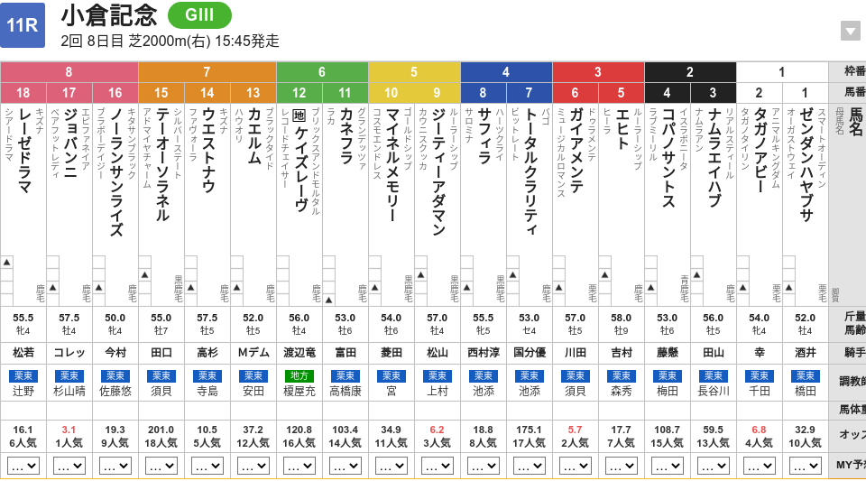

### 【函館2歳ステークス 2026/07/19(日) 】

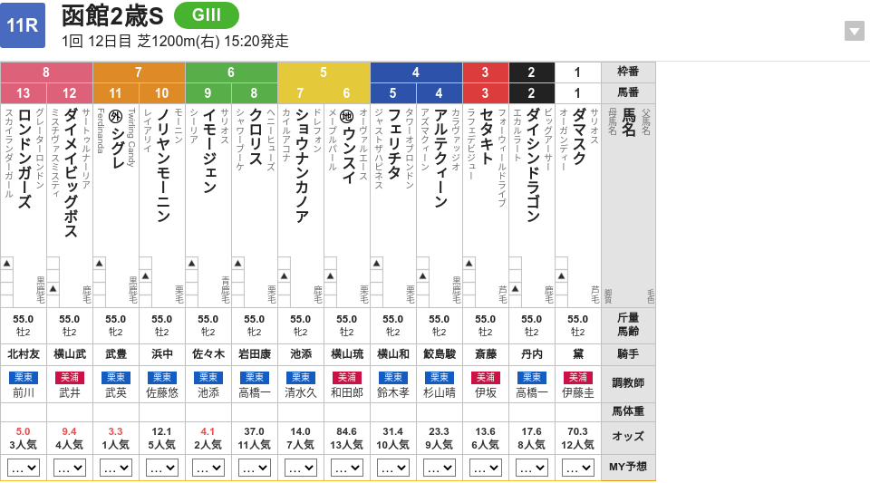

## 4. 単勝予測結果

### 【小倉記念(GⅢ) 2026/07/19(日)】

| 枠番 | 馬番 | 人気 | オッズ | 馬名 | 騎手 | 調教師 | 予測タイム(sec) | 1_順位 | 1-3着内確率(%) | 2_順位 | ﾀﾞｰｸﾎｰｽ確率(%) | 3_順位 |
| --- | --- | --- | --- | --- | --- | --- | --- | --- | --- | --- | --- | --- |
| 1 | 1 | 10 | 32.4 | ゼンダンハヤブサ | 酒井学 | 橋田宜長 | 125.5 | 12 | 10.4 | 11 | 39.0 | 6 |
| 1 | 2 | 4 | 6.8 | タガノアビー | 幸英明 | 千田輝彦 | 124.0 | 7 | 29.8 | 3 | 0.6 | 16 |
| 2 | 3 | 13 | 59.8 | ナムラエイハブ | 田山旺佑 | 長谷川浩大 | 125.3 | 11 | 7.2 | 13 | 57.7 | 5 |
| 2 | 4 | 15 | 108.3 | コパノサントス | 藤懸貴志 | 梅田智之 | 122.1 | 5 | 10.9 | 10 | 60.3 | 4 |
| 3 | 5 | 7 | 17.4 | エヒト | 吉村誠之助 | 森秀行 | 127.0 | 15 | 11.4 | 9 | 1.2 | 14 |
| 3 | 6 | 2 | 5.7 | ガイアメンテ | 川田将雅 | 須貝尚介 | 116.9 | 2 | 43.5 | 1 | 0.6 | 15 |
| 4 | 7 | 17 | 173.0 | トータルクラリティ | 国分優作 | 池添学 | 123.2 | 6 | 9.3 | 12 | 62.0 | 3 |
| 4 | 8 | 8 | 18.6 | サフィラ | 西村淳也 | 池添学 | 121.2 | 4 | 13.8 | 8 | 2.1 | 10 |
| 5 | 9 | 3 | 6.3 | ジーティーアダマン | 松山弘平 | 上村洋行 | 124.3 | 8 | 26.4 | 4 | 0.6 | 17 |
| 5 | 10 | 11 | 35.1 | マイネルメモリー | 菱田裕二 | 宮徹 | 116.9 | 2 | 17.8 | 7 | 68.7 | 1 |

[output cut: 8 more lines]

### 【函館2歳ステークス(GⅢ) 2026/07/19(日)】

| 枠番 | 馬番 | 人気 | オッズ | 馬名 | 騎手 | 調教師 | 予測タイム(sec) | 1_順位 | 1-3着内確率(%) | 2_順位 | ﾀﾞｰｸﾎｰｽ確率(%) | 3_順位 |
| --- | --- | --- | --- | --- | --- | --- | --- | --- | --- | --- | --- | --- |
| 1 | 1 | 12 | 72.3 | ダマスク | 黛弘人 | 伊藤圭三 | 72.2 | 2.0 | 10.0 | 9 | 44.9 | 1 |
| 2 | 2 | 8 | 17.5 | ダイシンドラゴン | 丹内祐次 | 高橋一哉 | 80.1 | 10.0 | 5.1 | 10 | 8.2 | 6 |
| 3 | 3 | 6 | 13.2 | セタキト | 斎藤新 | 伊坂重信 | 73.4 | 7.5 | 16.3 | 6 | 1.5 | 7 |
| 4 | 4 | 9 | 22.7 | アルテクィーン | 鮫島克駿 | 杉山晴紀 | 81.3 | 12.0 | 2.6 | 13 | 41.3 | 2 |
| 4 | 5 | 10 | 30.7 | フェリチタ | 横山和生 | 鈴木孝志 | 72.8 | 3.0 | 12.9 | 7 | 32.4 | 4 |
| 5 | 6 | 13 | 82.5 | ウンスイ | 横山琉人 | 和田正一郎 | 81.3 | 13.0 | 3.7 | 12 | 9.0 | 5 |
| 5 | 7 | 7 | 13.7 | ショウナンカノア | 池添謙一 | 清水久詞 | 80.3 | 11.0 | 4.6 | 11 | 0.7 | 10 |
| 6 | 8 | 11 | 38.0 | クロリス | 岩田康誠 | 高橋一哉 | 72.9 | 4.0 | 11.2 | 8 | 40.4 | 3 |
| 6 | 9 | 2 | 4.1 | イモージェン | 佐々木大輔 | 池添学 | 74.3 | 9.0 | 63.5 | 1 | 0.5 | 12 |
| 7 | 10 | 5 | 12.1 | ノリヤンモーニン | 浜中俊 | 佐藤悠太 | 73.4 | 7.5 | 21.2 | 3 | 1.4 | 8 |

[output cut: 3 more lines]

## 5. 人気と着順の乖離率推移

### 【小倉記念_1990y_2019y】

[interactive chart not shown]

### 【函館2歳ステークス_2001y_2019y】

[interactive chart not shown]

### 【小倉記念_1990y_2019y】

| No | 開催年 | 不整合率(%) | 頭数 | 人気別着順(1-3位) | 人気別着順(全体) |
| --- | --- | --- | --- | --- | --- |
| 30 | 2019 | 46.0 | 13頭 | 1-6-5 | 1\|6\|5\|4\|8\|10\|3\|7\|12\|11\|2\|13\|9 |
| 29 | 2018 | 16.8 | 12頭 | 1-2-5 | 1\|2\|5\|8\|6\|12\|3\|9\|10\|7\|11\|4 |
| 28 | 2017 | 48.2 | 13頭 | 4-2-6 | 4\|2\|6\|8\|9\|5\|13\|1\|7\|11\|3\|12\|10 |
| 27 | 2016 | 36.4 | 12頭 | 11-4-6 | 11\|4\|6\|1\|5\|8\|2\|9\|3\|7\|10\|12 |
| 26 | 2015 | 38.5 | 17頭 | 6-2-3 | 6\|2\|3\|8\|1\|4\|12\|10\|15\|7\|9\|5\|13\|17\|16\|11\|14 |
| 25 | 2014 | 51.9 | 14頭 | 3-6-2 | 3\|6\|2\|4\|9\|1\|5\|11\|7\|12\|14\|10\|8\|13 |
| 24 | 2013 | 41.2 | 15頭 | 3-5-1 | 3\|5\|1\|4\|6\|2\|12\|15\|10\|7\|8\|13\|9\|14\|11 |
| 23 | 2012 | 36.3 | 12頭 | 3-1-9 | 3\|1\|9\|2\|8\|7\|4\|10\|11\|5\|6\|12 |
| 22 | 2011 | 38.4 | 18頭 | 4-15-8 | 4\|15\|8\|5\|13\|1\|10\|16\|6\|2\|12\|14\|18\|3\|7\|17\|9\|11 |
| 21 | 2010 | 26.3 | 17頭 | 9-4-1 | 9\|4\|1\|2\|13\|12\|3\|5\|10\|15\|7\|11\|6\|17\|16\|8\|14 |

[output cut: 20 more lines]

### 【函館2歳ステークス_2001y_2019y】

| No | 開催年 | 不整合率(%) | 頭数 | 人気別着順(1-3位) | 人気別着順(全体) |
| --- | --- | --- | --- | --- | --- |
| 19 | 2019 | 48.1 | 15頭 | 4-2-11 | 4\|2\|11\|3\|1\|8\|13\|9\|15\|5\|12\|7\|10\|6\|14 |
| 18 | 2018 | 45.7 | 16頭 | 2-7-3 | 2\|7\|3\|9\|6\|12\|11\|4\|1\|8\|13\|15\|16\|5\|14\|10 |
| 17 | 2017 | 28.9 | 15頭 | 1-12-4 | 1\|12\|4\|8\|5\|2\|7\|10\|6\|9\|14\|3\|13\|15\|11 |
| 16 | 2016 | 22.8 | 16頭 | 2-1-13 | 2\|1\|13\|8\|3\|6\|4\|5\|14\|10\|9\|11\|12\|15\|7\|16 |
| 15 | 2015 | 32.0 | 16頭 | 1-3-10 | 1\|3\|10\|12\|6\|4\|2\|11\|13\|9\|7\|15\|8\|5\|14\|16 |
| 14 | 2014 | 41.3 | 16頭 | 4-11-2 | 4\|11\|2\|12\|1\|6\|7\|5\|8\|3\|15\|10\|13\|16\|14\|9 |
| 13 | 2013 | 30.6 | 16頭 | 1-9-8 | 1\|9\|8\|2\|5\|12\|10\|11\|15\|14\|7\|4\|6\|16\|13\|3 |
| 12 | 2012 | 49.9 | 16頭 | 3-5-2 | 3\|5\|2\|14\|1\|8\|6\|7\|11\|9\|4\|12\|13\|16\|10\|15 |
| 11 | 2011 | 40.6 | 13頭 | 2-5-4 | 2\|5\|4\|1\|7\|11\|6\|9\|10\|8\|3\|12\|13 |
| 10 | 2010 | 24.0 | 13頭 | 2-1-3 | 2\|1\|3\|6\|5\|12\|9\|8\|4\|11\|10\|13\|7 |

[output cut: 9 more lines]

## 6. 1-3番人気馬の着順分類予測

### 【小倉記念】

| 分類 | 凡例 | 発生確率(%) | 当該レース | 当該レースランク | 直近1年間 |
| --- | --- | --- | --- | --- | --- |
| 1: 1番人気のみ (1_pop1) | 1 \| * \| * | 18.6 | 0.67 | 0.94 | 0.37 |
| 4: 1,2番人気のみ (4_pop12) | 1 \| 2 \| * | 18.2 | 2.19 | 1.86 | 0.00 |
| 8: 1,2,3番人気すべて着外 (8_darkhorse) | * \| * \| * | 14.4 | 0.86 | 0.88 | 0.00 |
| 5: 1,3番人気のみ (5_pop13) | 1 \| 3 \| * | 13.5 | 0.97 | 1.17 | 0.00 |
| 6: 2,3番人気のみ (6_pop23) | 2 \| 3 \| * | 10.1 | 0.91 | 0.88 | 0.00 |
| 2: 2番人気のみ (2_pop2) | 2 \| * \| * | 9.4 | 1.13 | 0.44 | 0.19 |
| 3: 3番人気のみ (3_pop3) | 3 \| * \| * | 8.5 | 1.52 | 2.58 | 0.00 |
| 7: 1,2,3番人気すべて着内 (7_pop123) | 1 \| 2 \| 3 | 7.2 | 0.87 | 1.09 | 0.00 |

### 【函館2歳ステークス】

| 分類 | 凡例 | 発生確率(%) | 当該レース | 当該レースランク | 直近1年間 |
| --- | --- | --- | --- | --- | --- |
| 1: 1番人気のみ (1_pop1) | 1 \| * \| * | 18.2 | 2.27 | 0.92 | 0.36 |
| 4: 1,2番人気のみ (4_pop12) | 1 \| 2 \| * | 18.0 | 1.50 | 1.84 | 0.00 |
| 8: 1,2,3番人気すべて着外 (8_darkhorse) | * \| * \| * | 14.2 | 0.89 | 0.87 | 0.00 |
| 5: 1,3番人気のみ (5_pop13) | 1 \| 3 \| * | 13.5 | 1.69 | 1.17 | 0.00 |
| 2: 2番人気のみ (2_pop2) | 2 \| * \| * | 10.5 | 0.26 | 0.49 | 0.21 |
| 6: 2,3番人気のみ (6_pop23) | 2 \| 3 \| * | 10.0 | 0.83 | 0.87 | 0.00 |
| 3: 3番人気のみ (3_pop3) | 3 \| * \| * | 8.6 | 0.00 | 2.61 | 0.00 |
| 7: 1,2,3番人気すべて着内 (7_pop123) | 1 \| 2 \| 3 | 7.1 | 1.77 | 1.08 | 0.00 |

## 7. 3連複予測結果

### 【小倉記念(GⅢ) 2026/07/19(日)】

| 分類 | 馬番 | 枠番 | 人気 | 平均予測タイム(sec) | 1-3着内確率(%) | ﾀﾞｰｸﾎｰｽ確率(%) | 馬名 | 騎手 | 調教師 |
| --- | --- | --- | --- | --- | --- | --- | --- | --- | --- |
| 4: 1,2番人気のみ (4_pop12) | 17-6-2 | 8-3-1 | 1-2-4 | 119.27 | 3.93 | 0.00 | ジョバンニ \| ガイアメンテ \| タガノアビー | Ｊ．コレット \| 川田将雅 \| 幸英明 | 杉山晴紀 \| 須貝尚介 \| 千田輝彦 |
| 7: 1,2,3番人気すべて着内 (7_pop123) | 17-6-9 | 8-3-5 | 1-2-3 | 119.37 | 3.49 | 0.00 | ジョバンニ \| ガイアメンテ \| ジーティーアダマン | Ｊ．コレット \| 川田将雅 \| 松山弘平 | 杉山晴紀 \| 須貝尚介 \| 上村洋行 |
| 6: 2,3番人気のみ (6_pop23) | 6-9-2 | 3-5-1 | 2-3-4 | 121.73 | 3.42 | 0.00 | ガイアメンテ \| ジーティーアダマン \| タガノアビー | 川田将雅 \| 松山弘平 \| 幸英明 | 須貝尚介 \| 上村洋行 \| 千田輝彦 |
| 4: 1,2番人気のみ (4_pop12) | 17-6-14 | 8-3-7 | 1-2-5 | 119.37 | 2.84 | 0.00 | ジョバンニ \| ガイアメンテ \| ウエストナウ | Ｊ．コレット \| 川田将雅 \| 高杉吏麒 | 杉山晴紀 \| 須貝尚介 \| 寺島良 |
| 2: 2番人気のみ (2_pop2) | 6-2-14 | 3-1-7 | 2-4-5 | 121.73 | 2.78 | 0.00 | ガイアメンテ \| タガノアビー \| ウエストナウ | 川田将雅 \| 幸英明 \| 高杉吏麒 | 須貝尚介 \| 千田輝彦 \| 寺島良 |
| 6: 2,3番人気のみ (6_pop23) | 6-9-14 | 3-5-7 | 2-3-5 | 121.83 | 2.47 | 0.00 | ガイアメンテ \| ジーティーアダマン \| ウエストナウ | 川田将雅 \| 松山弘平 \| 高杉吏麒 | 須貝尚介 \| 上村洋行 \| 寺島良 |
| 5: 1,3番人気のみ (5_pop13) | 17-9-2 | 8-5-1 | 1-3-4 | 121.73 | 2.39 | 0.00 | ジョバンニ \| ジーティーアダマン \| タガノアビー | Ｊ．コレット \| 松山弘平 \| 幸英明 | 杉山晴紀 \| 上村洋行 \| 千田輝彦 |
| 4: 1,2番人気のみ (4_pop12) | 17-6-18 | 8-3-8 | 1-2-6 | 119.40 | 2.39 | 0.00 | ジョバンニ \| ガイアメンテ \| レーゼドラマ | Ｊ．コレット \| 川田将雅 \| 松若風馬 | 杉山晴紀 \| 須貝尚介 \| 辻野泰之 |
| 4: 1,2番人気のみ (4_pop12) | 17-6-10 | 8-3-5 | 1-2-11 | 116.90 | 2.35 | 0.00 | ジョバンニ \| ガイアメンテ \| マイネルメモリー | Ｊ．コレット \| 川田将雅 \| 菱田裕二 | 杉山晴紀 \| 須貝尚介 \| 宮徹 |
| 2: 2番人気のみ (2_pop2) | 6-2-18 | 3-1-8 | 2-4-6 | 121.77 | 2.34 | 0.00 | ガイアメンテ \| タガノアビー \| レーゼドラマ | 川田将雅 \| 幸英明 \| 松若風馬 | 須貝尚介 \| 千田輝彦 \| 辻野泰之 |

[output cut: 806 more lines]

### 【函館2歳ステークス(GⅢ) 2026/07/19(日)】

| 分類 | 馬番 | 枠番 | 人気 | 平均予測タイム(sec) | 1-3着内確率(%) | ﾀﾞｰｸﾎｰｽ確率(%) | 馬名 | 騎手 | 調教師 |
| --- | --- | --- | --- | --- | --- | --- | --- | --- | --- |
| 6: 2,3番人気のみ (6_pop23) | 9-13-10 | 6-8-7 | 2-3-5 | 73.57 | 3.83 | 0.00 | イモージェン \| ロンドンガーズ \| ノリヤンモーニン | 佐々木大輔 \| 北村友一 \| 浜中俊 | 池添学 \| 前川恭子 \| 佐藤悠太 |
| 6: 2,3番人気のみ (6_pop23) | 9-13-12 | 6-8-8 | 2-3-4 | 73.43 | 3.70 | 0.00 | イモージェン \| ロンドンガーズ \| ダイメイビッグボス | 佐々木大輔 \| 北村友一 \| 横山武史 | 池添学 \| 前川恭子 \| 武井亮 |
| 7: 1,2,3番人気すべて着内 (7_pop123) | 11-9-13 | 7-6-8 | 1-2-3 | 72.17 | 3.35 | 0.00 | シグレ \| イモージェン \| ロンドンガーズ | 武豊 \| 佐々木大輔 \| 北村友一 | 武英智 \| 池添学 \| 前川恭子 |
| 6: 2,3番人気のみ (6_pop23) | 9-13-3 | 6-8-3 | 2-3-6 | 73.57 | 2.95 | 0.00 | イモージェン \| ロンドンガーズ \| セタキト | 佐々木大輔 \| 北村友一 \| 斎藤新 | 池添学 \| 前川恭子 \| 伊坂重信 |
| 2: 2番人気のみ (2_pop2) | 9-12-10 | 6-8-7 | 2-4-5 | 73.57 | 2.75 | 0.00 | イモージェン \| ダイメイビッグボス \| ノリヤンモーニン | 佐々木大輔 \| 横山武史 \| 浜中俊 | 池添学 \| 武井亮 \| 佐藤悠太 |
| 4: 1,2番人気のみ (4_pop12) | 11-9-10 | 7-6-7 | 1-2-5 | 72.30 | 2.49 | 0.00 | シグレ \| イモージェン \| ノリヤンモーニン | 武豊 \| 佐々木大輔 \| 浜中俊 | 武英智 \| 池添学 \| 佐藤悠太 |
| 4: 1,2番人気のみ (4_pop12) | 11-9-12 | 7-6-8 | 1-2-4 | 72.17 | 2.40 | 0.00 | シグレ \| イモージェン \| ダイメイビッグボス | 武豊 \| 佐々木大輔 \| 横山武史 | 武英智 \| 池添学 \| 武井亮 |
| 6: 2,3番人気のみ (6_pop23) | 9-13-5 | 6-8-4 | 2-3-10 | 73.37 | 2.34 | 0.00 | イモージェン \| ロンドンガーズ \| フェリチタ | 佐々木大輔 \| 北村友一 \| 横山和生 | 池添学 \| 前川恭子 \| 鈴木孝志 |
| 2: 2番人気のみ (2_pop2) | 9-10-3 | 6-7-3 | 2-5-6 | 73.70 | 2.20 | 0.00 | イモージェン \| ノリヤンモーニン \| セタキト | 佐々木大輔 \| 浜中俊 \| 斎藤新 | 池添学 \| 佐藤悠太 \| 伊坂重信 |
| 2: 2番人気のみ (2_pop2) | 9-12-3 | 6-8-3 | 2-4-6 | 73.57 | 2.12 | 0.00 | イモージェン \| ダイメイビッグボス \| セタキト | 佐々木大輔 \| 横山武史 \| 斎藤新 | 池添学 \| 武井亮 \| 伊坂重信 |

[output cut: 276 more lines]

## 8. 直近の全レース情報

| No | 日付 | 競馬場 | R | 発走 | レース名 | 距離 | 頭数 | URL(netkeiba) |
| --- | --- | --- | --- | --- | --- | --- | --- | --- |
| 1 | 2026/07/18(土) | 03_福島 | 9R | 14:35 | 開成山特別 | 0 | 16頭 | https://race.netkeiba.com/race/shutuba.html?race_id=202603020709&amp;rf=race_list |
| 2 | 2026/07/18(土) | 03_福島 | 10R | 15:10 | 米沢特別 | 0 | 17頭 | https://race.netkeiba.com/race/shutuba.html?race_id=202603020710&amp;rf=race_list |
| 3 | 2026/07/18(土) | 03_福島 | 11R | 15:45 | 阿武隈S | 0 | 21頭 | https://race.netkeiba.com/race/shutuba.html?race_id=202603020711&amp;rf=race_list |
| 4 | 2026/07/18(土) | 10_小倉 | 4R | 11:30 | ソレイユJS | 0 | 8頭 | https://race.netkeiba.com/race/shutuba.html?race_id=202610020704&amp;rf=race_list |
| 5 | 2026/07/18(土) | 10_小倉 | 9R | 14:20 | ひまわり賞 | 0 | 18頭 | https://race.netkeiba.com/race/shutuba.html?race_id=202610020709&amp;rf=race_list |
| 6 | 2026/07/18(土) | 10_小倉 | 10R | 14:55 | 熊本城特別 | 0 | 14頭 | https://race.netkeiba.com/race/shutuba.html?race_id=202610020710&amp;rf=race_list |
| 7 | 2026/07/18(土) | 10_小倉 | 11R | 15:30 | テレQ杯 | 0 | 13頭 | https://race.netkeiba.com/race/shutuba.html?race_id=202610020711&amp;rf=race_list |
| 8 | 2026/07/18(土) | 02_函館 | 9R | 14:10 | 湯浜特別 | 0 | 19頭 | https://race.netkeiba.com/race/shutuba.html?race_id=202602011109&amp;rf=race_list |
| 9 | 2026/07/18(土) | 02_函館 | 10R | 14:45 | 潮騒特別 | 0 | 12頭 | https://race.netkeiba.com/race/shutuba.html?race_id=202602011110&amp;rf=race_list |
| 10 | 2026/07/18(土) | 02_函館 | 11R | 15:20 | マリーンS | 0 | 15頭 | https://race.netkeiba.com/race/shutuba.html?race_id=202602011111&amp;rf=race_list |

[output cut: 10 more lines]